# R Notebook

## Homework #1 - Boxplot Comparisons for Different Distributions

## Megan Daley and Shiru Wang

# I: Normal Distribution

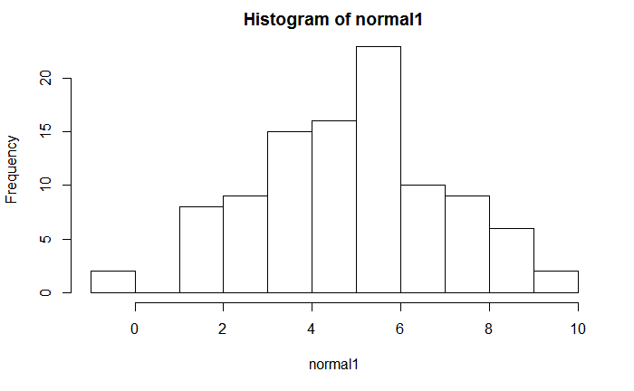

```r
normal1 <- rnorm(100, mean = 5, sd = 2)
hist(normal1)
median(normal1)
```

```
[1] 5.026964
```

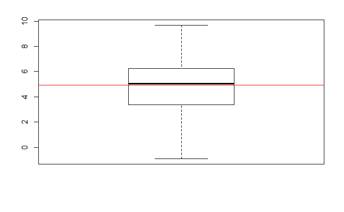

```r
boxplot(normal1)
xbar <- mean(normal1)
abline(h=xbar, col = 2)
```

# II: Normal Distribution, but with Extreme Outliers

We created a second distribution based on the first, but added in 23 additional numbers to act as outliers. The histogram shows a roughly normal distribution but with a negative skew. The boxplot below shows the distribution, with the green line representing the calculated mean of the sample dataset.

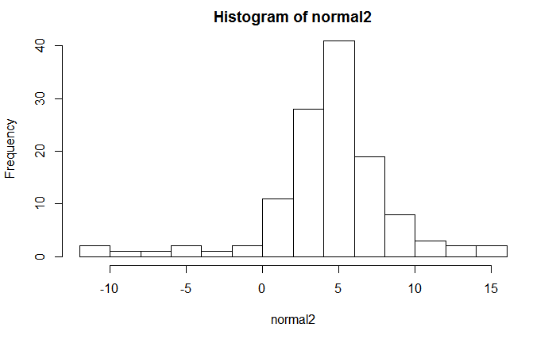

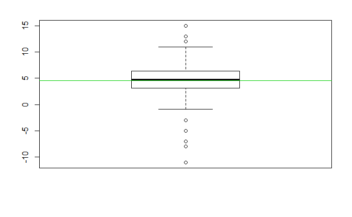

```r
normal2 <- c(normal1, 15, 15, 12, 11, 13, 13, 11, 6, 6, 4, 4, 3, 3, 2, 2, 2,-11,-11,-3,-5,-7,-8,-5)
xbar2 <- mean(normal2)
hist(normal2 ,breaks = 10)
boxplot(normal2)

abline(h = xbar2, col = 3)
```

# III: Uniform Distribution

We generated a uniform random distribution ranging from -15 to 15, with 100 values. The histogram shows a very even distribution. The boxplot below shows a positive skew distribution, with the blue line representing the calculated mean of the sample dataset.

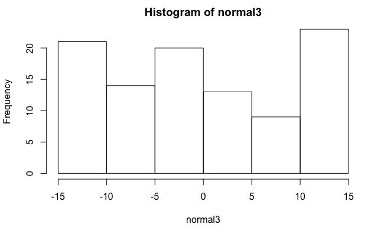

[figure not shown]